# Optimal Treatment Analysis

## Outcome Variable

**Outcome Variable:** whz

## Predictor Variables

**Intervention Variable:** nrooms

**Adjustment Set:**

- arm
- sex
- W_mage
- meducyrs
- feducyrs
- hhwealth_quart
- hfoodsec
- W_mhtcm
- W_nchldlt5
- W_parity
- impfloor
- impsan
- safeh20
- delta_W_mage
- delta_meducyrs
- delta_feducyrs
- delta_hhwealth_quart
- delta_hfoodsec
- delta_W_mhtcm
- delta_W_nchldlt5
- delta_W_parity
- delta_impfloor
- delta_impsan
- delta_safeh20

## Stratifying Variables

The analysis was stratified on these variable(s):

- agecat
- studyid
- country

## Data Summary

| agecat | studyid | country | nrooms | n_cell | n |
| --- | --- | --- | --- | --- | --- |
| Birth | ki0047075b-MAL-ED | BANGLADESH | 4+ | 12 | 222 |
| Birth | ki0047075b-MAL-ED | BANGLADESH | 1 | 135 | 222 |
| Birth | ki0047075b-MAL-ED | BANGLADESH | 2 | 47 | 222 |
| Birth | ki0047075b-MAL-ED | BANGLADESH | 3 | 28 | 222 |
| Birth | ki0047075b-MAL-ED | BRAZIL | 4+ | 99 | 167 |
| Birth | ki0047075b-MAL-ED | BRAZIL | 1 | 3 | 167 |
| Birth | ki0047075b-MAL-ED | BRAZIL | 2 | 19 | 167 |
| Birth | ki0047075b-MAL-ED | BRAZIL | 3 | 46 | 167 |
| Birth | ki0047075b-MAL-ED | INDIA | 4+ | 22 | 188 |
| Birth | ki0047075b-MAL-ED | INDIA | 1 | 68 | 188 |
| Birth | ki0047075b-MAL-ED | INDIA | 2 | 66 | 188 |
| Birth | ki0047075b-MAL-ED | INDIA | 3 | 32 | 188 |
| Birth | ki0047075b-MAL-ED | NEPAL | 4+ | 94 | 166 |
| Birth | ki0047075b-MAL-ED | NEPAL | 1 | 34 | 166 |
| Birth | ki0047075b-MAL-ED | NEPAL | 2 | 21 | 166 |
| Birth | ki0047075b-MAL-ED | NEPAL | 3 | 17 | 166 |
| Birth | ki0047075b-MAL-ED | PERU | 4+ | 127 | 252 |
| Birth | ki0047075b-MAL-ED | PERU | 1 | 17 | 252 |
| Birth | ki0047075b-MAL-ED | PERU | 2 | 51 | 252 |
| Birth | ki0047075b-MAL-ED | PERU | 3 | 57 | 252 |
| Birth | ki0047075b-MAL-ED | SOUTH AFRICA | 4+ | 159 | 216 |
| Birth | ki0047075b-MAL-ED | SOUTH AFRICA | 1 | 14 | 216 |
| Birth | ki0047075b-MAL-ED | SOUTH AFRICA | 2 | 20 | 216 |
| Birth | ki0047075b-MAL-ED | SOUTH AFRICA | 3 | 23 | 216 |
| Birth | ki0047075b-MAL-ED | TANZANIA, UNITED REPUBLIC OF | 4+ | 54 | 114 |
| Birth | ki0047075b-MAL-ED | TANZANIA, UNITED REPUBLIC OF | 1 | 6 | 114 |
| Birth | ki0047075b-MAL-ED | TANZANIA, UNITED REPUBLIC OF | 2 | 23 | 114 |
| Birth | ki0047075b-MAL-ED | TANZANIA, UNITED REPUBLIC OF | 3 | 31 | 114 |
| Birth | ki1000108-CMC-V-BCS-2002 | INDIA | 4+ | 5 | 88 |
| Birth | ki1000108-CMC-V-BCS-2002 | INDIA | 1 | 39 | 88 |

[output cut: 154 more lines]

The following strata were considered:

- agecat: 24 months, studyid: ki0047075b-MAL-ED, country: BANGLADESH
- agecat: 24 months, studyid: ki0047075b-MAL-ED, country: BRAZIL
- agecat: 24 months, studyid: ki0047075b-MAL-ED, country: INDIA
- agecat: 24 months, studyid: ki0047075b-MAL-ED, country: NEPAL
- agecat: 24 months, studyid: ki0047075b-MAL-ED, country: PERU
- agecat: 24 months, studyid: ki0047075b-MAL-ED, country: SOUTH AFRICA
- agecat: 24 months, studyid: ki0047075b-MAL-ED, country: TANZANIA, UNITED REPUBLIC OF
- agecat: 24 months, studyid: ki1000108-CMC-V-BCS-2002, country: INDIA
- agecat: 24 months, studyid: ki1000108-IRC, country: INDIA
- agecat: 24 months, studyid: ki1017093b-PROVIDE, country: BANGLADESH
- agecat: 24 months, studyid: ki1017093c-NIH-Crypto, country: BANGLADESH
- agecat: 24 months, studyid: ki1113344-GMS-Nepal, country: NEPAL
- agecat: 24 months, studyid: ki1114097-CONTENT, country: PERU
- agecat: 24 months, studyid: ki1135781-COHORTS, country: INDIA
- agecat: 24 months, studyid: kiGH5241-JiVitA-3, country: BANGLADESH
- agecat: 24 months, studyid: kiGH5241-JiVitA-4, country: BANGLADESH
- agecat: 6 months, studyid: ki0047075b-MAL-ED, country: BANGLADESH
- agecat: 6 months, studyid: ki0047075b-MAL-ED, country: BRAZIL
- agecat: 6 months, studyid: ki0047075b-MAL-ED, country: INDIA
- agecat: 6 months, studyid: ki0047075b-MAL-ED, country: NEPAL
- agecat: 6 months, studyid: ki0047075b-MAL-ED, country: PERU
- agecat: 6 months, studyid: ki0047075b-MAL-ED, country: SOUTH AFRICA
- agecat: 6 months, studyid: ki0047075b-MAL-ED, country: TANZANIA, UNITED REPUBLIC OF
- agecat: 6 months, studyid: ki1000108-CMC-V-BCS-2002, country: INDIA
- agecat: 6 months, studyid: ki1000108-IRC, country: INDIA
- agecat: 6 months, studyid: ki1017093b-PROVIDE, country: BANGLADESH
- agecat: 6 months, studyid: ki1017093c-NIH-Crypto, country: BANGLADESH
- agecat: 6 months, studyid: ki1113344-GMS-Nepal, country: NEPAL
- agecat: 6 months, studyid: ki1114097-CONTENT, country: PERU
- agecat: 6 months, studyid: ki1135781-COHORTS, country: INDIA
- agecat: 6 months, studyid: kiGH5241-JiVitA-3, country: BANGLADESH
- agecat: 6 months, studyid: kiGH5241-JiVitA-4, country: BANGLADESH
- agecat: Birth, studyid: ki0047075b-MAL-ED, country: BANGLADESH
- agecat: Birth, studyid: ki0047075b-MAL-ED, country: BRAZIL
- agecat: Birth, studyid: ki0047075b-MAL-ED, country: INDIA
- agecat: Birth, studyid: ki0047075b-MAL-ED, country: NEPAL
- agecat: Birth, studyid: ki0047075b-MAL-ED, country: PERU
- agecat: Birth, studyid: ki0047075b-MAL-ED, country: SOUTH AFRICA
- agecat: Birth, studyid: ki0047075b-MAL-ED, country: TANZANIA, UNITED REPUBLIC OF
- agecat: Birth, studyid: ki1000108-CMC-V-BCS-2002, country: INDIA
- agecat: Birth, studyid: ki1000108-IRC, country: INDIA
- agecat: Birth, studyid: ki1017093c-NIH-Crypto, country: BANGLADESH
- agecat: Birth, studyid: ki1114097-CONTENT, country: PERU
- agecat: Birth, studyid: ki1135781-COHORTS, country: INDIA
- agecat: Birth, studyid: kiGH5241-JiVitA-3, country: BANGLADESH
- agecat: Birth, studyid: kiGH5241-JiVitA-4, country: BANGLADESH

### Dropped Strata

Some strata were dropped due to rare outcomes:

- agecat: Birth, studyid: ki0047075b-MAL-ED, country: BRAZIL
- agecat: Birth, studyid: ki1017093c-NIH-Crypto, country: BANGLADESH
- agecat: Birth, studyid: ki1114097-CONTENT, country: PERU
- agecat: 6 months, studyid: ki0047075b-MAL-ED, country: BRAZIL
- agecat: 24 months, studyid: ki0047075b-MAL-ED, country: BRAZIL

## Methods Detail

We’re interested in the causal parameters $E[Y_a]$ for all values of $a \in \mathcal{A}$. These parameters represent the mean outcome if, possibly contrary to fact, we intervened to set all units to have $A=a$. Under the randomization and positivity assumptions, these are identified by the statistical parameters $\psi_a=E_W[E_{Y|A,W}(Y|A=a,W)]$. In addition, we’re interested in the mean of $Y$, $E[Y]$ under no intervention (the observed mean). We will estimate these parameters by using SuperLearner to fit the relevant likelihood factors – $E_{Y|A,W}(Y|A=a,W)$ and $p(A=a|W)$, and then updating our likelihood fit using a joint TMLE.

For unadjusted analyses ($W=\{\}$), initial likelihoods were estimated using Lrnr_glm to estimate the simple $E(Y|A)$ and Lrnr_mean to estimate $p(A)$. For adjusted analyses, a small library containing Lrnr_glmnet, Lrnr_xgboost, and Lrnr_mean was used.

# Results Detail

## Results Plots

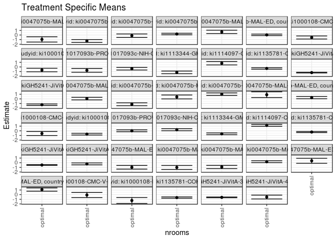

## Results Table

### Parameter: TSM

| agecat | studyid | country | intervention_level | baseline_level | estimate | ci_lower | ci_upper |
| --- | --- | --- | --- | --- | --- | --- | --- |
| Birth | ki0047075b-MAL-ED | BANGLADESH | optimal | observed | -0.9725935 | -1.3753300 | -0.5698570 |
| Birth | ki0047075b-MAL-ED | INDIA | optimal | observed | -1.0154277 | -1.4514266 | -0.5794287 |
| Birth | ki0047075b-MAL-ED | NEPAL | optimal | observed | -0.9171751 | -1.2702031 | -0.5641470 |
| Birth | ki0047075b-MAL-ED | PERU | optimal | observed | 0.2153531 | 0.0074637 | 0.4232426 |
| Birth | ki0047075b-MAL-ED | SOUTH AFRICA | optimal | observed | 0.4193169 | -0.1193438 | 0.9579776 |
| Birth | ki0047075b-MAL-ED | TANZANIA, UNITED REPUBLIC OF | optimal | observed | 1.0982177 | 0.7465104 | 1.4499249 |
| Birth | ki1000108-CMC-V-BCS-2002 | INDIA | optimal | observed | -0.0763117 | -0.6386801 | 0.4860567 |
| Birth | ki1000108-IRC | INDIA | optimal | observed | -1.2615095 | -1.8964914 | -0.6265277 |
| Birth | ki1135781-COHORTS | INDIA | optimal | observed | -0.6298744 | -0.7772199 | -0.4825289 |
| Birth | kiGH5241-JiVitA-3 | BANGLADESH | optimal | observed | -0.5863726 | -0.6655219 | -0.5072234 |
| Birth | kiGH5241-JiVitA-4 | BANGLADESH | optimal | observed | -0.5157683 | -0.9286333 | -0.1029034 |
| 6 months | ki0047075b-MAL-ED | BANGLADESH | optimal | observed | 0.0588422 | -0.2211246 | 0.3388090 |
| 6 months | ki0047075b-MAL-ED | INDIA | optimal | observed | -1.1630267 | -1.4796136 | -0.8464399 |
| 6 months | ki0047075b-MAL-ED | NEPAL | optimal | observed | 0.4145568 | -0.0058034 | 0.8349169 |
| 6 months | ki0047075b-MAL-ED | PERU | optimal | observed | 1.0206250 | 0.7473279 | 1.2939221 |
| 6 months | ki0047075b-MAL-ED | SOUTH AFRICA | optimal | observed | 0.8955337 | 0.2666338 | 1.5244336 |
| 6 months | ki0047075b-MAL-ED | TANZANIA, UNITED REPUBLIC OF | optimal | observed | 0.2691668 | 0.0250080 | 0.5133256 |
| 6 months | ki1000108-CMC-V-BCS-2002 | INDIA | optimal | observed | -0.5842488 | -1.0313705 | -0.1371271 |
| 6 months | ki1000108-IRC | INDIA | optimal | observed | -0.7271196 | -0.9159258 | -0.5383133 |
| 6 months | ki1017093b-PROVIDE | BANGLADESH | optimal | observed | 0.0056440 | -0.2027297 | 0.2140177 |
| 6 months | ki1017093c-NIH-Crypto | BANGLADESH | optimal | observed | 0.2319215 | 0.0107886 | 0.4530543 |
| 6 months | ki1113344-GMS-Nepal | NEPAL | optimal | observed | -0.6502797 | -0.8468730 | -0.4536865 |
| 6 months | ki1114097-CONTENT | PERU | optimal | observed | 1.1711146 | 0.9695654 | 1.3726637 |
| 6 months | ki1135781-COHORTS | INDIA | optimal | observed | -0.2683271 | -0.3905286 | -0.1461256 |
| 6 months | kiGH5241-JiVitA-3 | BANGLADESH | optimal | observed | -0.4910991 | -0.5671645 | -0.4150336 |
| 6 months | kiGH5241-JiVitA-4 | BANGLADESH | optimal | observed | -0.2472860 | -0.4546945 | -0.0398775 |
| 24 months | ki0047075b-MAL-ED | BANGLADESH | optimal | observed | -0.9504426 | -1.5204489 | -0.3804364 |
| 24 months | ki0047075b-MAL-ED | INDIA | optimal | observed | -1.2902825 | -1.5866128 | -0.9939521 |
| 24 months | ki0047075b-MAL-ED | NEPAL | optimal | observed | -0.1405540 | -0.5087837 | 0.2276757 |
| 24 months | ki0047075b-MAL-ED | PERU | optimal | observed | 0.2147649 | 0.0503863 | 0.3791436 |
| 24 months | ki0047075b-MAL-ED | SOUTH AFRICA | optimal | observed | 0.6635283 | 0.2939720 | 1.0330846 |
| 24 months | ki0047075b-MAL-ED | TANZANIA, UNITED REPUBLIC OF | optimal | observed | 0.0270571 | -0.1391100 | 0.1932242 |
| 24 months | ki1000108-CMC-V-BCS-2002 | INDIA | optimal | observed | -0.5352899 | -0.8652853 | -0.2052945 |
| 24 months | ki1000108-IRC | INDIA | optimal | observed | -0.6664810 | -1.0474453 | -0.2855167 |
| 24 months | ki1017093b-PROVIDE | BANGLADESH | optimal | observed | -0.7347671 | -1.1468703 | -0.3226639 |
| 24 months | ki1017093c-NIH-Crypto | BANGLADESH | optimal | observed | -0.3801503 | -0.6706424 | -0.0896582 |
| 24 months | ki1113344-GMS-Nepal | NEPAL | optimal | observed | -1.1728618 | -1.4620935 | -0.8836301 |
| 24 months | ki1114097-CONTENT | PERU | optimal | observed | 0.8057735 | 0.4378581 | 1.1736888 |
| 24 months | ki1135781-COHORTS | INDIA | optimal | observed | -0.3272288 | -0.4878411 | -0.1666166 |
| 24 months | kiGH5241-JiVitA-3 | BANGLADESH | optimal | observed | -1.2229672 | -1.2990987 | -1.1468358 |
| 24 months | kiGH5241-JiVitA-4 | BANGLADESH | optimal | observed | -1.2629909 | -1.4259661 | -1.1000156 |

### Parameter: E(Y)

| agecat | studyid | country | intervention_level | baseline_level | estimate | ci_lower | ci_upper |
| --- | --- | --- | --- | --- | --- | --- | --- |
| Birth | ki0047075b-MAL-ED | BANGLADESH | observed | observed | -0.9902252 | -1.1311070 | -0.8493435 |
| Birth | ki0047075b-MAL-ED | INDIA | observed | observed | -1.0536702 | -1.1965043 | -0.9108361 |
| Birth | ki0047075b-MAL-ED | NEPAL | observed | observed | -0.9174699 | -1.0573845 | -0.7775553 |
| Birth | ki0047075b-MAL-ED | PERU | observed | observed | -0.0384921 | -0.1542085 | 0.0772244 |
| Birth | ki0047075b-MAL-ED | SOUTH AFRICA | observed | observed | -0.0073148 | -0.1632037 | 0.1485740 |
| Birth | ki0047075b-MAL-ED | TANZANIA, UNITED REPUBLIC OF | observed | observed | 0.8024561 | 0.5990025 | 1.0059098 |
| Birth | ki1000108-CMC-V-BCS-2002 | INDIA | observed | observed | -0.6275000 | -0.9746292 | -0.2803708 |
| Birth | ki1000108-IRC | INDIA | observed | observed | -1.0053372 | -1.1922119 | -0.8184626 |
| Birth | ki1135781-COHORTS | INDIA | observed | observed | -0.9778087 | -1.0126530 | -0.9429644 |
| Birth | kiGH5241-JiVitA-3 | BANGLADESH | observed | observed | -0.7238563 | -0.7437124 | -0.7040002 |
| Birth | kiGH5241-JiVitA-4 | BANGLADESH | observed | observed | -0.3683163 | -0.4490504 | -0.2875821 |
| 6 months | ki0047075b-MAL-ED | BANGLADESH | observed | observed | -0.1354618 | -0.2647919 | -0.0061317 |
| 6 months | ki0047075b-MAL-ED | INDIA | observed | observed | -0.7056667 | -0.8312524 | -0.5800810 |
| 6 months | ki0047075b-MAL-ED | NEPAL | observed | observed | 0.1110452 | -0.0202712 | 0.2423616 |
| 6 months | ki0047075b-MAL-ED | PERU | observed | observed | 1.0527407 | 0.9299728 | 1.1755087 |
| 6 months | ki0047075b-MAL-ED | SOUTH AFRICA | observed | observed | 0.5403280 | 0.3866002 | 0.6940558 |
| 6 months | ki0047075b-MAL-ED | TANZANIA, UNITED REPUBLIC OF | observed | observed | 0.5170513 | 0.3872178 | 0.6468847 |
| 6 months | ki1000108-CMC-V-BCS-2002 | INDIA | observed | observed | -0.5026766 | -0.6536848 | -0.3516685 |
| 6 months | ki1000108-IRC | INDIA | observed | observed | -0.5900821 | -0.7252457 | -0.4549185 |
| 6 months | ki1017093b-PROVIDE | BANGLADESH | observed | observed | -0.2083706 | -0.2927992 | -0.1239419 |
| 6 months | ki1017093c-NIH-Crypto | BANGLADESH | observed | observed | 0.0297622 | -0.0491685 | 0.1086930 |
| 6 months | ki1113344-GMS-Nepal | NEPAL | observed | observed | -0.6047987 | -0.6909649 | -0.5186325 |
| 6 months | ki1114097-CONTENT | PERU | observed | observed | 1.0684318 | 0.9515274 | 1.1853362 |
| 6 months | ki1135781-COHORTS | INDIA | observed | observed | -0.7088012 | -0.7411274 | -0.6764750 |
| 6 months | kiGH5241-JiVitA-3 | BANGLADESH | observed | observed | -0.5930302 | -0.6125738 | -0.5734865 |
| 6 months | kiGH5241-JiVitA-4 | BANGLADESH | observed | observed | -0.3901595 | -0.4274150 | -0.3529041 |
| 24 months | ki0047075b-MAL-ED | BANGLADESH | observed | observed | -0.8208255 | -0.9429246 | -0.6987264 |
| 24 months | ki0047075b-MAL-ED | INDIA | observed | observed | -0.9522907 | -1.0676596 | -0.8369219 |
| 24 months | ki0047075b-MAL-ED | NEPAL | observed | observed | -0.3764474 | -0.4898516 | -0.2630431 |
| 24 months | ki0047075b-MAL-ED | PERU | observed | observed | 0.1199005 | -0.0000331 | 0.2398341 |
| 24 months | ki0047075b-MAL-ED | SOUTH AFRICA | observed | observed | 0.4267017 | 0.3074751 | 0.5459283 |
| 24 months | ki0047075b-MAL-ED | TANZANIA, UNITED REPUBLIC OF | observed | observed | 0.0500935 | -0.0748234 | 0.1750103 |
| 24 months | ki1000108-CMC-V-BCS-2002 | INDIA | observed | observed | -0.5571505 | -0.6585247 | -0.4557763 |
| 24 months | ki1000108-IRC | INDIA | observed | observed | -0.7416790 | -0.8323562 | -0.6510017 |
| 24 months | ki1017093b-PROVIDE | BANGLADESH | observed | observed | -0.8879412 | -0.9708680 | -0.8050144 |
| 24 months | ki1017093c-NIH-Crypto | BANGLADESH | observed | observed | -0.6103502 | -0.7050157 | -0.5156847 |
| 24 months | ki1113344-GMS-Nepal | NEPAL | observed | observed | -1.1315863 | -1.2192240 | -1.0439487 |
| 24 months | ki1114097-CONTENT | PERU | observed | observed | 0.5668293 | 0.4302437 | 0.7034148 |
| 24 months | ki1135781-COHORTS | INDIA | observed | observed | -0.6612799 | -0.6944511 | -0.6281088 |
| 24 months | kiGH5241-JiVitA-3 | BANGLADESH | observed | observed | -1.2967966 | -1.3200807 | -1.2735126 |
| 24 months | kiGH5241-JiVitA-4 | BANGLADESH | observed | observed | -1.2231776 | -1.2550332 | -1.1913220 |

### Parameter: PAR

| agecat | studyid | country | intervention_level | baseline_level | estimate | ci_lower | ci_upper |
| --- | --- | --- | --- | --- | --- | --- | --- |
| Birth | ki0047075b-MAL-ED | BANGLADESH | optimal | observed | -0.0176317 | -0.4169690 | 0.3817056 |
| Birth | ki0047075b-MAL-ED | INDIA | optimal | observed | -0.0382425 | -0.4382483 | 0.3617632 |
| Birth | ki0047075b-MAL-ED | NEPAL | optimal | observed | -0.0002948 | -0.3323291 | 0.3317394 |
| Birth | ki0047075b-MAL-ED | PERU | optimal | observed | -0.2538452 | -0.4481447 | -0.0595458 |
| Birth | ki0047075b-MAL-ED | SOUTH AFRICA | optimal | observed | -0.4266317 | -0.9416490 | 0.0883857 |
| Birth | ki0047075b-MAL-ED | TANZANIA, UNITED REPUBLIC OF | optimal | observed | -0.2957615 | -0.6401010 | 0.0485780 |
| Birth | ki1000108-CMC-V-BCS-2002 | INDIA | optimal | observed | -0.5511883 | -1.1111990 | 0.0088224 |
| Birth | ki1000108-IRC | INDIA | optimal | observed | 0.2561723 | -0.3633071 | 0.8756517 |
| Birth | ki1135781-COHORTS | INDIA | optimal | observed | -0.3479343 | -0.4951052 | -0.2007634 |
| Birth | kiGH5241-JiVitA-3 | BANGLADESH | optimal | observed | -0.1374837 | -0.2155014 | -0.0594659 |
| Birth | kiGH5241-JiVitA-4 | BANGLADESH | optimal | observed | 0.1474521 | -0.2553875 | 0.5502917 |
| 6 months | ki0047075b-MAL-ED | BANGLADESH | optimal | observed | -0.1943040 | -0.4468448 | 0.0582369 |
| 6 months | ki0047075b-MAL-ED | INDIA | optimal | observed | 0.4573601 | 0.1674442 | 0.7472760 |
| 6 months | ki0047075b-MAL-ED | NEPAL | optimal | observed | -0.3035116 | -0.6922577 | 0.0852346 |
| 6 months | ki0047075b-MAL-ED | PERU | optimal | observed | 0.0321158 | -0.2255857 | 0.2898172 |
| 6 months | ki0047075b-MAL-ED | SOUTH AFRICA | optimal | observed | -0.3552057 | -0.9576608 | 0.2472494 |
| 6 months | ki0047075b-MAL-ED | TANZANIA, UNITED REPUBLIC OF | optimal | observed | 0.2478845 | 0.0138302 | 0.4819389 |
| 6 months | ki1000108-CMC-V-BCS-2002 | INDIA | optimal | observed | 0.0815721 | -0.3314872 | 0.4946315 |
| 6 months | ki1000108-IRC | INDIA | optimal | observed | 0.1370375 | -0.0375295 | 0.3116044 |
| 6 months | ki1017093b-PROVIDE | BANGLADESH | optimal | observed | -0.2140146 | -0.4075234 | -0.0205057 |
| 6 months | ki1017093c-NIH-Crypto | BANGLADESH | optimal | observed | -0.2021592 | -0.4083763 | 0.0040579 |
| 6 months | ki1113344-GMS-Nepal | NEPAL | optimal | observed | 0.0454810 | -0.1271794 | 0.2181414 |
| 6 months | ki1114097-CONTENT | PERU | optimal | observed | -0.1026828 | -0.2635374 | 0.0581718 |
| 6 months | ki1135781-COHORTS | INDIA | optimal | observed | -0.4404741 | -0.5634420 | -0.3175062 |
| 6 months | kiGH5241-JiVitA-3 | BANGLADESH | optimal | observed | -0.1019311 | -0.1769455 | -0.0269168 |
| 6 months | kiGH5241-JiVitA-4 | BANGLADESH | optimal | observed | -0.1428735 | -0.3404644 | 0.0547174 |
| 24 months | ki0047075b-MAL-ED | BANGLADESH | optimal | observed | 0.1296172 | -0.4161084 | 0.6753428 |
| 24 months | ki0047075b-MAL-ED | INDIA | optimal | observed | 0.3379917 | 0.0594183 | 0.6165652 |
| 24 months | ki0047075b-MAL-ED | NEPAL | optimal | observed | -0.2358934 | -0.5784118 | 0.1066250 |
| 24 months | ki0047075b-MAL-ED | PERU | optimal | observed | -0.0948644 | -0.2043998 | 0.0146710 |
| 24 months | ki0047075b-MAL-ED | SOUTH AFRICA | optimal | observed | -0.2368267 | -0.6006225 | 0.1269692 |
| 24 months | ki0047075b-MAL-ED | TANZANIA, UNITED REPUBLIC OF | optimal | observed | 0.0230364 | -0.1201494 | 0.1662222 |
| 24 months | ki1000108-CMC-V-BCS-2002 | INDIA | optimal | observed | -0.0218606 | -0.3403098 | 0.2965886 |
| 24 months | ki1000108-IRC | INDIA | optimal | observed | -0.0751979 | -0.4436994 | 0.2933036 |
| 24 months | ki1017093b-PROVIDE | BANGLADESH | optimal | observed | -0.1531741 | -0.5577021 | 0.2513540 |
| 24 months | ki1017093c-NIH-Crypto | BANGLADESH | optimal | observed | -0.2301999 | -0.4969505 | 0.0365507 |
| 24 months | ki1113344-GMS-Nepal | NEPAL | optimal | observed | 0.0412755 | -0.2326243 | 0.3151752 |
| 24 months | ki1114097-CONTENT | PERU | optimal | observed | -0.2389442 | -0.5523406 | 0.0744522 |
| 24 months | ki1135781-COHORTS | INDIA | optimal | observed | -0.3340511 | -0.4933295 | -0.1747727 |
| 24 months | kiGH5241-JiVitA-3 | BANGLADESH | optimal | observed | -0.0738294 | -0.1480688 | 0.0004100 |
| 24 months | kiGH5241-JiVitA-4 | BANGLADESH | optimal | observed | 0.0398133 | -0.1133689 | 0.1929955 |